# TRABAJO FIN DE MÁSTER: DETECCIÓN TEMPRANA DE SEPSIS

#### **6. k-NN**

Para el algoritmo kNN (k vecinos más cercanos) es importante tener en cuenta una consideración previa: este algoritmo calcula la similitud entre variables usando la **distancia** entre las mismas. Esto significa que dichas distancias deben ser comparables, y los rangos de valores entre las variables deben ser similares.

Esto implica que debemos **normalizar** algunas de nuestras variables para que funcione el algoritmo. Una manera de hacerlo es definiendo una función y luego aplicarla para las columnas correspondientes de nuestro dataset:

```r
normalizar <- function(variable){
  (variable - min(variable)) / (max(variable) - min(variable))
}
```

```r
datos_normalizados <- data_outcome
```

```r
datos_normalizados$Age <- normalizar(datos_normalizados$Age)  # Normalización: EDAD
datos_normalizados$Initial.PCT.value <- normalizar(datos_normalizados$Initial.PCT.value)  # Normalización: PCT VALUE
datos_normalizados$PaO2 <- normalizar(datos_normalizados$PaO2)  # Normalización: PaO2
datos_normalizados$FiO2 <- normalizar(datos_normalizados$FiO2)  # Normalización: FiO2
datos_normalizados$Platelets <- normalizar(datos_normalizados$Platelets)  # Normalización: PLATELETS
datos_normalizados$Bilirubin <- normalizar(datos_normalizados$Bilirubin)  # Normalización: BILIRUBIN
datos_normalizados$GCS <- normalizar(datos_normalizados$GCS)  # Normalización: GCS
datos_normalizados$MAP <- normalizar(datos_normalizados$MAP)  # Normalización: MAP
datos_normalizados$Creatinine <- normalizar(datos_normalizados$Creatinine)  # Normalización: CREATININE
datos_normalizados$UOP <- normalizar(datos_normalizados$UOP)  # Normalización: UOP
datos_normalizados$LOS <- normalizar(datos_normalizados$LOS)  # Normalización: LOS
```

Una vez realizada la normalización de las variables no binarias, vamos a dividir los datos en entrenamiento y test. Usamos la misma partición que para los algoritmos anteriores:

```r
train_outcome_kNN <- datos_normalizados[indice,]
test_outcome_kNN <- datos_normalizados[-indice,]
```

Entrenamos nuestro modelo:

```r
set.seed(14)

outcome_knn_train <- train(as.factor(Outcome) ~ .,
                  data = train_outcome_kNN,
                  method = "knn",
                  trControl = CV_outcome,
                  tuneLength = 20)
```

```r
outcome_knn_train
```

```
k-Nearest Neighbors

255 samples
 35 predictor
  4 classes: '1', '2', '3', '4'

No pre-processing
Resampling: Cross-Validated (10 fold)
Summary of sample sizes: 229, 229, 231, 230, 229, 229, ...
Resampling results across tuning parameters:

  k   Accuracy   Kappa
   5  0.5217350  0.1721618
   7  0.5017094  0.1343785
   9  0.5000256  0.1363394
  11  0.5092578  0.1511145
  13  0.4941695  0.1277856
  15  0.5097080  0.1549992
  17  0.5132450  0.1557430
  19  0.5050783  0.1373545
  21  0.5136966  0.1563777
  23  0.5052450  0.1394723
  25  0.5244744  0.1744742
  27  0.4935285  0.1176512
  29  0.5124501  0.1513177
  31  0.5201667  0.1676831
  33  0.5007835  0.1307838
  35  0.4970912  0.1259191
  37  0.5281909  0.1826690
  39  0.5123319  0.1506312
  41  0.5206410  0.1648364
  43  0.5284872  0.1794802

Accuracy was used to select the optimal model using the largest value.
The final value used for the model was k = 43.
```

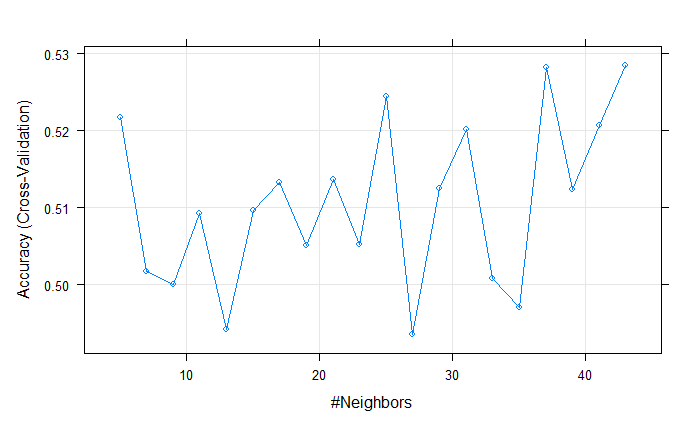

```r
plot(outcome_knn_train)
```

Utilizamos el modelo para predecir sobre el conjunto de test:

```r
outcome_knn_predict <- predict(outcome_knn_train, test_outcome_kNN)
```

Creamos la matriz de confusión:

```r
matriz_knn_outcome <- confusionMatrix(as.factor(outcome_knn_predict),
                                            as.factor(test_outcome$Outcome),
                                            mode = "everything")
matriz_knn_outcome
```

```
Confusion Matrix and Statistics

          Reference
Prediction  1  2  3  4
         1 28  0  3 27
         2  0  0  0  0
         3  0  0  0  0
         4  9  1  9 32

Overall Statistics

               Accuracy : 0.5505
                 95% CI : (0.4522, 0.6459)
    No Information Rate : 0.5413
    P-Value [Acc > NIR] : 0.4628

                  Kappa : 0.2059

 Mcnemar's Test P-Value : NA

Statistics by Class:

                     Class: 1 Class: 2 Class: 3 Class: 4
Sensitivity            0.7568 0.000000   0.0000   0.5424
Specificity            0.5833 1.000000   1.0000   0.6200
Pos Pred Value         0.4828      NaN      NaN   0.6275
Neg Pred Value         0.8235 0.990826   0.8899   0.5345
Precision              0.4828       NA       NA   0.6275
Recall                 0.7568 0.000000   0.0000   0.5424
F1                     0.5895       NA       NA   0.5818
Prevalence             0.3394 0.009174   0.1101   0.5413
Detection Rate         0.2569 0.000000   0.0000   0.2936
Detection Prevalence   0.5321 0.000000   0.0000   0.4679
Balanced Accuracy      0.6700 0.500000   0.5000   0.5812
```

#### **7. NAIVE-BAYES**

Instalamos las librerías necesarias para aplicar el algoritmo:

```r
library("klaR")
```

```r
library(e1071)
```

Entrenamos nuestro modelo:

```r
set.seed(14)

outcome_nb_train <- train(as.factor(Outcome) ~ .,
                          data = train_outcome,
                          method = "nb",
                          trControl = CV_outcome)
```

A continuación podemos ver el resultado del entrenamiento:

```r
outcome_nb_train
```

```
Naive Bayes

255 samples
 35 predictor
  4 classes: '1', '2', '3', '4'

No pre-processing
Resampling: Cross-Validated (10 fold)
Summary of sample sizes: 229, 229, 231, 230, 229, 229, ...
Resampling results across tuning parameters:

  usekernel  Accuracy   Kappa
  FALSE            NaN        NaN
   TRUE      0.5795175  0.2506234

Tuning parameter 'fL' was held constant at a value of 0
Tuning parameter 'adjust' was held constant at a value of 1
Accuracy was used to select the optimal model using the largest value.
The final values used for the model were fL = 0, usekernel = TRUE and adjust = 1.
```

```r
outcome_nb_predict <- predict(outcome_nb_train, test_outcome)
```

Creamos la matriz de confusión:

```r
matriz_nb_outcome <- confusionMatrix(as.factor(outcome_nb_predict),
                                            as.factor(test_outcome$Outcome),
                                            mode = "everything")
matriz_nb_outcome
```

```
Confusion Matrix and Statistics

          Reference
Prediction  1  2  3  4
         1 26  0  2 15
         2  0  0  0  0
         3  0  0  0  0
         4 11  1 10 44

Overall Statistics

               Accuracy : 0.6422
                 95% CI : (0.5447, 0.7317)
    No Information Rate : 0.5413
    P-Value [Acc > NIR] : 0.0211

                  Kappa : 0.3354

 Mcnemar's Test P-Value : NA

Statistics by Class:

                     Class: 1 Class: 2 Class: 3 Class: 4
Sensitivity            0.7027 0.000000   0.0000   0.7458
Specificity            0.7639 1.000000   1.0000   0.5600
Pos Pred Value         0.6047      NaN      NaN   0.6667
Neg Pred Value         0.8333 0.990826   0.8899   0.6512
Precision              0.6047       NA       NA   0.6667
Recall                 0.7027 0.000000   0.0000   0.7458
F1                     0.6500       NA       NA   0.7040
Prevalence             0.3394 0.009174   0.1101   0.5413
Detection Rate         0.2385 0.000000   0.0000   0.4037
Detection Prevalence   0.3945 0.000000   0.0000   0.6055
Balanced Accuracy      0.7333 0.500000   0.5000   0.6529
```

## **8. MÁQUINA DE VECTORES DE SOPORTE LINEAL**

En primer lugar, entrenamos nuestro modelo:

```r
set.seed(14)

outcome_SVM_train <- train(as.factor(Outcome) ~ .,
                  data = train_outcome,
                  method = "svmLinear",
                  trControl = CV_outcome,
                  tuneLength = 20)
```

```r
outcome_SVM_train
```

```
Support Vector Machines with Linear Kernel

255 samples
 35 predictor
  4 classes: '1', '2', '3', '4'

No pre-processing
Resampling: Cross-Validated (10 fold)
Summary of sample sizes: 229, 229, 231, 230, 229, 229, ...
Resampling results:

  Accuracy   Kappa
  0.5408091  0.2284264

Tuning parameter 'C' was held constant at a value of 1
```

Utilizamos el modelo para predecir sobre el conjunto de test:

```r
outcome_SVM_predict <- predict(outcome_SVM_train, test_outcome)
```

Creamos la matriz de confusión:

```r
matriz_SVM_outcome <- confusionMatrix(as.factor(outcome_SVM_predict),
                                            as.factor(test_outcome$Outcome),
                                            mode = "everything")
matriz_SVM_outcome
```

```
Confusion Matrix and Statistics

          Reference
Prediction  1  2  3  4
         1 24  0  2 19
         2  0  0  0  4
         3  2  0  2  2
         4 11  1  8 34

Overall Statistics

               Accuracy : 0.5505
                 95% CI : (0.4522, 0.6459)
    No Information Rate : 0.5413
    P-Value [Acc > NIR] : 0.4628

                  Kappa : 0.232

 Mcnemar's Test P-Value : NA

Statistics by Class:

                     Class: 1 Class: 2 Class: 3 Class: 4
Sensitivity            0.6486 0.000000  0.16667   0.5763
Specificity            0.7083 0.962963  0.95876   0.6000
Pos Pred Value         0.5333 0.000000  0.33333   0.6296
Neg Pred Value         0.7969 0.990476  0.90291   0.5455
Precision              0.5333 0.000000  0.33333   0.6296
Recall                 0.6486 0.000000  0.16667   0.5763
F1                     0.5854      NaN  0.22222   0.6018
Prevalence             0.3394 0.009174  0.11009   0.5413
Detection Rate         0.2202 0.000000  0.01835   0.3119
Detection Prevalence   0.4128 0.036697  0.05505   0.4954
Balanced Accuracy      0.6785 0.481481  0.56271   0.5881
```

## **9. MÁQUINA DE VECTORES DE SOPORTE KERNEL**

En primer lugar, entrenamos nuestro modelo:

```r
set.seed(14)

outcome_kernel_train <- train(as.factor(Outcome) ~ .,
                  data = train_outcome,
                  method = "svmRadial",
                  trControl = CV_outcome,
                  tuneLength = 20)
```

```r
outcome_kernel_train
```

```
Support Vector Machines with Radial Basis Function Kernel

255 samples
 35 predictor
  4 classes: '1', '2', '3', '4'

No pre-processing
Resampling: Cross-Validated (10 fold)
Summary of sample sizes: 229, 229, 231, 230, 229, 229, ...
Resampling results across tuning parameters:

  C          Accuracy   Kappa
       0.25  0.5581866  0.1844198
       0.50  0.5377108  0.1640007
       1.00  0.5332251  0.1628025
       2.00  0.5127607  0.1407173
       4.00  0.5082977  0.1450972
       8.00  0.4850442  0.1090736
      16.00  0.5238362  0.1818503
      32.00  0.5481937  0.2380609
      64.00  0.5171054  0.1937775
     128.00  0.4866467  0.1436570
     256.00  0.4943390  0.1573913
     512.00  0.4863262  0.1421642
    1024.00  0.4826225  0.1341152
    2048.00  0.4826225  0.1341152
    4096.00  0.4826225  0.1341152
    8192.00  0.4826225  0.1341152
   16384.00  0.4826225  0.1341152
   32768.00  0.4826225  0.1341152
   65536.00  0.4826225  0.1341152
  131072.00  0.4826225  0.1341152

Tuning parameter 'sigma' was held constant at a value of 0.0001562867
Accuracy was used to select the optimal model using the largest value.
The final values used for the model were sigma = 0.0001562867 and C = 0.25.
```

Utilizamos el modelo para predecir sobre el conjunto de test:

```r
outcome_kernel_predict <- predict(outcome_kernel_train, test_outcome)
```

Creamos la matriz de confusión:

```r
matriz_kernel_outcome <- confusionMatrix(as.factor(outcome_kernel_predict),
                                            as.factor(test_outcome$Outcome),
                                            mode = "everything")
matriz_kernel_outcome
```

```
Confusion Matrix and Statistics

          Reference
Prediction  1  2  3  4
         1 18  0  2 21
         2  0  0  0  0
         3  0  0  0  0
         4 19  1 10 38

Overall Statistics

               Accuracy : 0.5138
                 95% CI : (0.4161, 0.6106)
    No Information Rate : 0.5413
    P-Value [Acc > NIR] : 0.7498

                  Kappa : 0.0905

 Mcnemar's Test P-Value : NA

Statistics by Class:

                     Class: 1 Class: 2 Class: 3 Class: 4
Sensitivity            0.4865 0.000000   0.0000   0.6441
Specificity            0.6806 1.000000   1.0000   0.4000
Pos Pred Value         0.4390      NaN      NaN   0.5588
Neg Pred Value         0.7206 0.990826   0.8899   0.4878
Precision              0.4390       NA       NA   0.5588
Recall                 0.4865 0.000000   0.0000   0.6441
F1                     0.4615       NA       NA   0.5984
Prevalence             0.3394 0.009174   0.1101   0.5413
Detection Rate         0.1651 0.000000   0.0000   0.3486
Detection Prevalence   0.3761 0.000000   0.0000   0.6239
Balanced Accuracy      0.5835 0.500000   0.5000   0.5220
```